# TP bioinfo IFSBM UE Big Data

Modèles prédictifs

Loic Verlingue, Md, PhDc loic.verlingue@gustaveroussy.fr

# Get familiar with R Notebook

### Execute code

```r
 #Try executing this chunk by clicking the *Run* button within the chunk or by placing your cursor inside it and pressing *Ctrl+Enter*.
print("Welcome to 'Big Data et modèles prédictifs' practical session")
```

```
[1] "Welcome to 'Big Data et modèles prédictifs' practical session"
```

```r
set.seed(1234)
```

# Load your material

## a short list of important genes

The Cancer Gene Census, CGS, is a selection of important genes for cancer devellopment. To load the [Cancer Gene Census](https://cancer.sanger.ac.uk/census) table you need a login. To facilitate your work, I have provided it to you. You simply have to run the following cell.

```r
urlfile<-"https://raw.githubusercontent.com/gustaveroussy/IFSBM-bigdata/master/TP_IFSBM_module12/2020/labs/lab_2/data/CancerGeneCensusCOSMIC.csv"
CGS<-read.csv(urlfile,stringsAsFactors = F)
GENES<-CGS$Gene.Symbol[CGS$Hallmark=="Yes"]
print(paste("You have selected",length(GENES),"important cancer genes like:", paste(sample(GENES,20), collapse = ", "), "..."))
```

```
[1] "You have selected 251 important cancer genes like: B2M, IL6ST, HNRNPA2B1, IGH, RAD21, JAK2, ACKR3, CBL, KEAP1, FANCD2, LMNA, FGFR1, CDH11, RECQL4, CDK4, PPARG, TFE3, CCNE1, BRIP1, CASP8 ..."
```

## Data from TCGA

Now you need data from [TCGA](https://cancergenome.nih.gov/)!

The TCGA is a database containing clinical and molecular data (Whole Exome, RNASeq, microarray and others) and clinical information such as survival from several thousand American patients. This anonymized data is accessible: to access the raw data you will need the authorization of a data user commitee. Instead the processed data is free of access. It can nevertheless be difficult to retrieve this data by hand and then load it into R.

For you, I have built a function that will load the data you need from a list of genes and cancer types. The processed data comes from [cBioportal](http://www.cbioportal.org/), a reference web site widely used for the exploration and downloading of TCGA data. For that you will need to install the official cBioportal R package [cgdsr](http://www.cbioportal.org/rmatlab) and my function [LoadcBioportal150119.R](https://github.com/DITEP/TPBigDataIFSBM) (if you are curious you can go and check the source code of this function).

```r
#source("https://raw.githubusercontent.com/DITEP/TPBigDataIFSBM/master/LoadcBioportal150119.R")
source("https://raw.githubusercontent.com/gustaveroussy/IFSBM-bigdata/master/TP_IFSBM_module12/2020/labs/lib/LoadcBioportal150119.R")
```

You will also need some other usefull R packages such as:

- the [glmnet](https://cran.r-project.org/web/packages/glmnet/glmnet.pdf) package to compute linear models
- the [survival](https://cran.r-project.org/web/packages/survival/survival.pdf) package to analyse survival data

```r
library(reshape2)
library(glmnet)
library(survival)
library(cgdsr)
```

# Use LoadcBioportal() function

You will also query only the important genes `GENES` selected before (otherwise it could be very long).

```r
STUDY<-TCGAdata$STUDY
print("Here are your patients' numbers:")
```

```
[1] "Here are your patients' numbers:"
```

```r
print(table(TCGAdata$CLINIC$study))
```

```
 gbm luad
 141  230
```

Tis function returns a list called `TCGAdata` where each request is stored under the following names:

```r
names(TCGAdata)
```

```
[1] "MUT"    "EXP"    "CLINIC" "STUDY"
```

*rescue only, else skip* EXP<-read.csv2(“https://github.com/gustaveroussy/IFSBM-bigdata/tree/master/TP_IFSBM_module12/2020/labs/lab_2/data/EXPlung_gbm.csv”, row.names = 1) CLINIC<-read.csv2(“https://github.com/gustaveroussy/IFSBM-bigdata/tree/master/TP_IFSBM_module12/2020/labs/lab_2/data/Cliniclung_gbm.csv”, row.names = 1) TCGAdata<-list() TCGAdata[“EXP”]<-EXP TCGAdata[“CLINIC”]<-CLINIC *end rescue only*

It is of good practice to check the dimension of your data. The dimensions are in the form [N rows, N columns].

```r
# check dimensions of your data
lapply(TCGAdata,dim)
```

```
$MUT
[1] 0 0

$EXP
[1] 371 250

$CLINIC
[1] 371   3

$STUDY
[1] 4 1
```

See you didn’t load mutation data because of the argument `MutNeeded = F` so the dimensions of the `TCGAdata$MUT` is [0,0]. The function has selected and sorted the patients so that you have a `TCGAdata$EXP` and `TCGAdata$CLINIC`with the same patients as rows and no NAs.

# Your first classifier

Can you identify the organ of origin from the gene expressions?

*Look at the slides!*

## First step, slit your cohorts.

```r
# split
TrainSplit=0.8
Train<-sample(seq(nrow(TCGAdata$CLINIC)),size = round(nrow(TCGAdata$CLINIC)*TrainSplit) )
Val<-seq(nrow(TCGAdata$CLINIC))[!seq(nrow(TCGAdata$CLINIC))%in%Train]
paste("Your training and validation cohorts have",length(Train),"&", length(Val), "patients")
```

```
[1] "Your training and validation cohorts have 297 & 74 patients"
```

### Quizz

4. Why did we split the cohort?

your answer here:

## Second step, train your logistic regression model.

[glmnet](https://cran.r-project.org/web/packages/glmnet/glmnet.pdf) is a great tool: glm stands for Generalized Linear Models and net for some regularization procedures (optional, set to 0 here). The `family` argument stands for the type of model to use: here you have 2 classes (binomial) and you want to use a traditional logistic regression.

```r
# logistic regression fit
LRfit<-glmnet(as.matrix(TCGAdata$EXP[Train,]),as.factor(TCGAdata$CLINIC$study[Train]),
              family = "binomial", alpha = 0, lambda = 0)
```

### Quizz

5. On which cohort is it best to evaluate the prediction of your model?

your answer here:

## Third step, evaluate the predictions on the test set.

```r
# preds
Preds<-predict(LRfit,as.matrix(TCGAdata$EXP[Val,]),type = "class")
table(Preds,TCGAdata$CLINIC$study[Val])
```

```
Preds  gbm luad
  gbm   31    0
  luad   0   43
```

### Quizz

6. What is the name of such matrix representing true values and predictied values?

your answer here:

7. What is the [accuracy](https://en.wikipedia.org/wiki/Confusion_matrix) of your current predictions (help in the hyperlink)?

your answer here:

# Interpret things biologically

Ok, now you have a very good model to classify between lung cancers and glioblastoma from several gene expression, congratulation!

But maybe you are curious and you want to now what are the genes that are the most important to make such good predictions.

Look at the slides to check out how you can obtain that.

Choose the number of best genes you want to look at (in the cell).

```r
Ngenes=20
paste("Your top", Ngenes, "genes are:")
```

```
[1] "Your top 20 genes are:"
```

```r
as.matrix(coefficients(LRfit))[head(order(abs(coefficients(LRfit)),decreasing = T),Ngenes),,drop=F]
```

```
<sparse>[ <logic> ] : .M.sub.i.logical() maybe inefficient
```

```
               s0
ABL1    -87.74383
APC     -46.91240
AFF1     43.02512
BRD4     40.96320
ARNT     35.94399
ACVR1    32.42524
ATF1     30.12799
GNAQ     29.32255
ARID1A   28.70562
XPO1     26.49163
DDX6    -26.16191
ABI1    -23.88105
PPM1D    23.80645
ACKR3   -23.75469
ATRX     21.87786
SMAD3   -21.63575
EWSR1    21.58780
PRKAR1A -21.30022
CREBBP   21.20178
ERG      21.04913
```

### Quizz

8. Can you say these best 20 gene expressions can determine the tumor type as good as 251?

your answer here:

# Are there better ways to do so?

Say you want to have a limited list of important genes in your model. It can be useful if a biotech wants to devellop a gene signature to determine the tissue of origin of a cancer sample, for example. It is more or less a regularization (or penalization) procedure: you penalize your model by keeping a limited number of genes.

An existing procedure is Lasso (or L1N) regularization, that increases your cost during training. *Look at the slides for explanations*

Lasso (like other regularization procedures) comes with an additional parameter to optimize, here $\lambda$. The recommended way to find $\lambda$ is with k-fold cross validation strategy.

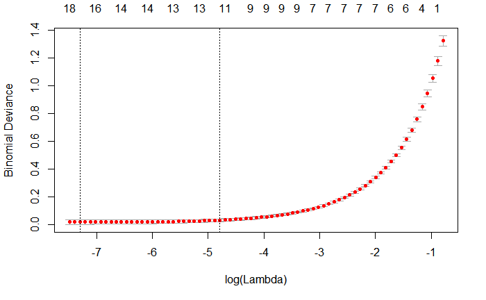

```r
# choose your lambda with cross validation  (CV)
LRcv<-cv.glmnet(as.matrix(TCGAdata$EXP[Train,]),as.factor(TCGAdata$CLINIC$study[Train]),
                family = "binomial",alpha = 1, nfolds = 10)
plot(LRcv)
```

```r
print(paste("You best value of lambda is :", LRcv$lambda.min))
```

```
[1] "You best value of lambda is : 0.000674601443478494"
```

### Quizz

9. Do you think this model needs important regularization to generalize well, and why (max 2 reasons)?

your answer here:

Then build your final model.

```r
# logistic regression fit
LRfitReduced<-glmnet(as.matrix(TCGAdata$EXP[Train,]),as.factor(TCGAdata$CLINIC$study[Train]),
              family = "binomial", alpha = 1, lambda = LRcv$lambda.min)
#plot(LRfitReduced)
Preds<-predict(LRfitReduced,as.matrix(TCGAdata$EXP[Val,]),type = "class")
table(Preds,TCGAdata$CLINIC$study[Val])
```

```
Preds  gbm luad
  gbm   31    0
  luad   0   43
```

### Quizz

10. Has Lasso regularization changed the accuracy of your model?

your answer here:

Check the selected genes.

```r
COEF<-as.matrix(coefficients(LRfitReduced))
GoodCOEF<-COEF[COEF[,1]!=0,,drop=F]
paste("The selected", nrow(GoodCOEF), "genes are:")
```

```
[1] "The selected 17 genes are:"
```

```r
GoodCOEF[order(abs(GoodCOEF[,1]),decreasing = T),,drop=F]
```

```
                    s0
QKI         -10.709287
HEY1         -8.298516
CDH1          5.639557
FOXA1         5.250713
(Intercept)   4.743394
ROS1          4.436813
LRP1B        -3.822033
EIF3E         3.770956
RNF43         3.710123
POU2AF1       3.311123
FGFR2        -1.852700
PRKACA       -1.780691
ERBB4        -1.764786
GAS7         -1.682732
CCDC6         1.347903
PTK6          1.295938
ATP2B3       -0.970295
```

### Quizz

11. If you go to see a clinician and tell him about your new model, do you think he will want to use it?

your answer here:

# A glimpse into survival analysis

The function LoadcBioportal() also loads the survival data from TCGA patients when available. Look at the slides to learn what is a survival data.

```r
# load luad and gbm data
TCGAdata<-LoadcBioportal(Genes = GENES, Organ = "luad",
                         ClinicNeeded = T, MutNeeded = F,
                         RNANeeded = T, NormalizeRNA = T,
                         FunctionalAnnot = F, PDF = F, Tests=T)

# change status format to numerical
TCGAdata$CLINIC$OS_STATUS<-ifelse(TCGAdata$CLINIC$OS_STATUS=="LIVING",0,1)
```

### Quizz

15. What is the `TCGAdata$CLINIC$OS_STATUS` refering to?

your answer here:

Unfortunatly, there are some NAs and zeros follow up for some patients in TCGA data: we need to discard them.

```r
# remove NAS & Zeros follow up
NoNAS<-!is.na(TCGAdata$CLINIC$OS_MONTHS)
table(NoNAS)
NoZeros<-TCGAdata$CLINIC$OS_MONTHS!=0
table(NoZeros)
if(!all(NoNAS&NoZeros)){
  TCGAdata<-lapply(TCGAdata[1:3],function(VAR){
    VAR[NoNAS&NoZeros,]
  })
}
lapply(TCGAdata,dim)
```

Get familiar with the R representation of survival data. *look at the slides*

```r
# look at survival data
print(Surv(TCGAdata$CLINIC$OS_MONTHS, TCGAdata$CLINIC$OS_STATUS))
```

# Non parametric probability of survival

The `survfit()` function of the survival package compute the cumulative probability of survival that takes into acount censored data in the calculation.

At each time step $l$, the cumulative probability $P_{l}$ is calculated by:

$P_{l} = P_{l-1} \cdot \left( \frac{ NatRisk_{l}- Ndeath_{l} }{ NatRisk_{l}} \right)$

```r
survival <- survfit(Surv(TCGAdata$CLINIC$OS_MONTHS, TCGAdata$CLINIC$OS_STATUS)~NULL)
summary(survival)
```

[output not shown]

The cumulative probability of survival allow you to plot the Kaplan-Meier curve, which is a classical way to visualize the distribution of the survival data accross the cohort.

```r
# plot survival data
plot(survfit(Surv(time = TCGAdata$CLINIC$OS_MONTHS, event = TCGAdata$CLINIC$OS_STATUS)~NULL),mark.time = T,
     main="Kaplan Meier curves per organs",
     ylab="Probability of survival", xlab="Time in months")
```

[output not shown]

# A semi-parametric model survival: the Cox model

Previously your task was to classify the histologies from expression data. Your new task is to predict survival of patients, still from the gene expression.

Modeling survival looks like a regression task because you have numeric data to predict. However the way to perform your regression is adapted to the presence of censored data. The Cox model is using each variable (here gene expression) to model survival data (look at the slides). *look at the slides*

```r
## COX ###

# split
TrainSplit=0.8
Train<-sample(seq(nrow(TCGAdata$CLINIC)),size = round(nrow(TCGAdata$CLINIC)*TrainSplit) )
Val<-seq(nrow(TCGAdata$CLINIC))[!seq(nrow(TCGAdata$CLINIC))%in%Train]


Coxfit<-glmnet(as.matrix(TCGAdata$EXP[Train,]),
               Surv(TCGAdata$CLINIC$OS_MONTHS[Train],TCGAdata$CLINIC$OS_STATUS[Train]),
               family = "cox", alpha = 1, lambda = 0.15)

Preds<-predict(Coxfit,as.matrix(TCGAdata$EXP[Train,]),type = "response")
```

Evaluate the efficacy of your predictions with survival data. Concordance index is a classical metric (look at the slides). 1 or 0 are perfect concordances and 0.5 is random. *look at the slides*

```r
# check how well your learning has performed on the training set
Conc<-survConcordance(Surv(TCGAdata$CLINIC$OS_MONTHS[Train],TCGAdata$CLINIC$OS_STATUS[Train])~Preds)

plot(TCGAdata$CLINIC$OS_MONTHS[Train],(Preds),pch=TCGAdata$CLINIC$OS_STATUS[Train]+2, col=ifelse(TCGAdata$CLINIC$study[Train]=="luad",1,2))
print(Conc$concordance)
```

[output not shown]

```r
# check how well your learning has performed on the test set

Preds<-predict(Coxfit,as.matrix(TCGAdata$EXP[Val,]),type = "response")
Conc<-survConcordance(Surv(TCGAdata$CLINIC$OS_MONTHS[Val],TCGAdata$CLINIC$OS_STATUS[Val])~Preds)
plot(TCGAdata$CLINIC$OS_MONTHS[Val],(Preds),pch=TCGAdata$CLINIC$OS_STATUS[Val]+2, col=ifelse(TCGAdata$CLINIC$study[Val]=="luad",1,2))
print(Conc$concordance)
```

[output not shown]

## Quizz bonus

your answer here:

# End

In this workshop you have learned 2 classical machine learning approaches: classification and regression. We have addressed the challenge of modeling high dimension data (gene expression) to predict clinically relevant observations.

I hope you have gained experience on the good practices in machine learning and the main residing challenges. Maybe these scripts can be usefull for your current or futur research, don’t hesitate to use it.

If you want to push foward the adventure, please contact me: loic.verlingue@gustaveroussy.fr . You can also visit our github github.com/DITEP to see what we are working on in our Data Science team.

Thank you!